# IBM_CHALLENGE

```python
import geopandas as gpd
#!pip install descartes


import pandas as pd
import matplotlib.pyplot as plt
import numpy as np

#!pip install folium
import json
#import folium
#from folium import Choropleth, Circle, Marker
#from folium.plugins import HeatMap, MarkerCluster

from bokeh.io import output_notebook, show, output_file
from bokeh.plotting import figure
from bokeh.models import GeoJSONDataSource, LinearColorMapper, ColorBar
from bokeh.palettes import brewer
```

```python
sales_data = pd.read_excel('Book1.xlsx')
```

```python
sales_data.info()
```

```
<class 'pandas.core.frame.DataFrame'>
RangeIndex: 21239 entries, 0 to 21238
Data columns (total 9 columns):
DATE                 21239 non-null datetime64[ns]
CLIENT_ID            21239 non-null int64
CLIENT_SIZE          21239 non-null object
INDUSTRY             21239 non-null object
STATE                21239 non-null object
PRODUCT              21239 non-null object
NUM_LICENSE          21239 non-null int64
PRICE_PER_LICENSE    21239 non-null float64
CSat                 20158 non-null float64
dtypes: datetime64[ns](1), float64(2), int64(2), object(4)
memory usage: 1.5+ MB
```

```python
sales_data['CSat'].unique()
```

```
array([ 6.,  7.,  5.,  9.,  4., 10.,  8., nan,  3.,  2.,  1.])
```

```python
sales_data['CSat'] = sales_data['CSat'].fillna(0)
sales_data.info()
```

[output not shown]

```python
sales_data['INDUSTRY'].unique()
```

```
array(['IT', 'HEALTH CARE', 'RETAIL', 'REAL ESTATE', 'FINANCE'],
      dtype=object)
```

```python
sales_data['PRODUCT'].unique()
```

```
array(['A', 'B', 'D', 'C', 'E'], dtype=object)
```

```python
sales_data['year'] = sales_data['DATE'].dt.year
```

# SLIDE 2 code and analysis

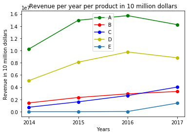

```python
sales_data['revenue'] = sales_data['NUM_LICENSE']*sales_data['PRICE_PER_LICENSE']

products = sales_data['PRODUCT'].unique()
years = sales_data['year'].unique()
var = sales_data[['PRODUCT','year','revenue']]
plot_data = dict()
for i in products:
    k = list()
    for j in years:
        k.append(var[(var['PRODUCT'] == i)&(var['year']==j)]['revenue'].sum())
    plot_data[i] = k

plt.plot(years,plot_data['A'],'g-',label='A',marker='o')
plt.plot(years,plot_data['B'],'r-',label='B',marker='o')
plt.plot(years,plot_data['C'],'b-',label='C',marker='o')
plt.plot(years,plot_data['D'],'y-',label='D',marker='o')
plt.plot(years,plot_data['E'],'o-',label='E',marker='o')

plt.xlabel("Years");
plt.ylabel("Revenue in 10 million dollars");
plt.title("Revenue per year per product in 10 million dollars");
plt.xticks(years);
plt.legend();
plt.savefig("Revenue per year per product.png");
```

```python
growth = list()
for i in products:
    ind = plot_data[i].index(next(filter(lambda x: x!=0, plot_data[i])))
    growth.append([i,round(plot_data[i][-1]-plot_data[i][ind],2),round((plot_data[i][-1]-plot_data[i][ind])/plot_data[i][ind],2)])
growth.sort(key=lambda x:x[2],reverse=True)
print("The highest growing product is {} with a {}% revenue increase from its inception till date".format(growth[0][0],growth[0][2]))
```

```
The highest growing product is E with a 42.11% revenue increase from its inception till date
```

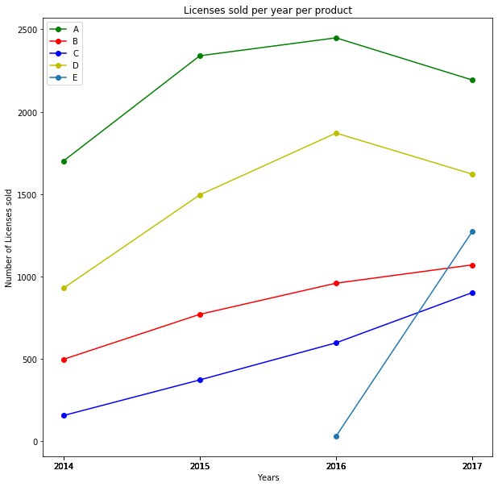

```python
x = pd.DataFrame(sales_data.groupby(['PRODUCT','year']).size())
x = x.rename(columns={0:'sales_per_year'})
x = x.reset_index(level=['PRODUCT', 'year'])

plt.figure(figsize=(10,10))
plt.plot(x[x['PRODUCT'] == 'A']['year'],x[x['PRODUCT'] == 'A']['sales_per_year'],'g-',marker='o',label='A')
plt.plot(x[x['PRODUCT'] == 'B']['year'],x[x['PRODUCT'] == 'B']['sales_per_year'],'r-',marker='o',label='B')
plt.plot(x[x['PRODUCT'] == 'C']['year'],x[x['PRODUCT'] == 'C']['sales_per_year'],'b-',marker='o',label='C')
plt.plot(x[x['PRODUCT'] == 'D']['year'],x[x['PRODUCT'] == 'D']['sales_per_year'],'y-',marker='o',label='D')
plt.plot(x[x['PRODUCT'] == 'E']['year'],x[x['PRODUCT'] == 'E']['sales_per_year'],'o-',marker='o',label='E')

plt.legend(loc=0)
plt.xlabel("Years");
plt.ylabel("Number of Licenses sold");
plt.xticks(x['year']);
plt.title("Licenses sold per year per product");
plt.savefig("Licenses sold per year per product.png");
#x[x['PRODUCT'] == 'B'].plot('year','sales_per_year',marker='o',label='B',xticks=x['year'])
```

```python
products = x['PRODUCT'].unique()
years = x['year'].unique()
plot_numbers = dict()
for i in products:
    plot_numbers[i] = list(x[(x['PRODUCT'] == i)]['sales_per_year'])
#plot_numbers

growth_numbers = list()
for i in products:
    growth_numbers.append([i,plot_numbers[i][-1]-plot_numbers[i][0],round((plot_numbers[i][-1]-plot_numbers[i][0])/plot_numbers[i][0],2)])
growth_numbers.sort(key=lambda x:x[2],reverse=True)
print("The highest growing product is {} with a {}% sales (number of licenses) increase from its inception till date".format(growth_numbers[0][0],growth_numbers[0][2]))
```

[output not shown]

```python
#This can be a little misleading because E is just released 1 year back let's go back a little
#if we exclude E then let's see
print("The highest growing product is {} with a {}% sales increase from its inception till date".format(growth_numbers[1][0],growth_numbers[1][2]))
print("The highest growing product is {} with a {}% revenue increase from its inception till date".format(growth[1][0],growth[1][2]))
```

```
The highest growing product is C with a 4.75% sales increase from its inception till date
The highest growing product is C with a 4.56% revenue increase from its inception till date
```

```
Increase in revenue by 54.0% from year 2014 to year 2015
Increase in revenue by 15.0% from year 2015 to year 2016
Increase in revenue by 2.0% from year 2016 to year 2017



Increase in revenue by 82.0% from year 2014 to year 2017
```

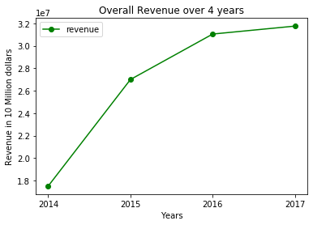

```python
rev = []
years = sales_data['year'].unique()
for i in years:
    rev.append(sales_data[sales_data['year']==i]['revenue'].sum())
plt.plot(years,rev,'g-',marker='o',label='revenue')
plt.xticks(years)
plt.legend(loc=0)
plt.xlabel("Years")
plt.ylabel("Revenue in 10 Million dollars")
plt.title("Overall Revenue over 4 years");
plt.savefig("Overall Revenue over 4 years.png")
for i in range(len(rev)-1):
    print("Increase in revenue by {}% from year {} to year {}".format(100*round((rev[i+1]-rev[i])/rev[i],2), years[i],years[i+1]))
print("\n\n\nIncrease in revenue by {}% from year {} to year {}".format(100*round((rev[-1]-rev[0])/rev[0],2), years[0],years[-1]))
```

```
Increase in sales by 56.99999999999999% from year 2014 to year 2015
Increase in sales by 18.0% from year 2015 to year 2016
Increase in sales by 19.0% from year 2016 to year 2017



Increase in sales by 121.0% from year 2014 to year 2017
```

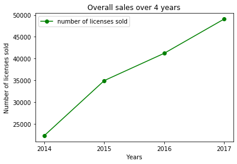

```python
sal = []
years = sales_data['year'].unique()
for i in years:
    sal.append(sales_data[sales_data['year']==i]['NUM_LICENSE'].sum())
plt.plot(years,sal,'g-',marker='o',label='number of licenses sold')
plt.xticks(years)
plt.legend(loc=0)
plt.xlabel("Years")
plt.ylabel("Number of licenses sold")
plt.title("Overall sales over 4 years");
plt.savefig("Overall sales over 4 years.png")
for i in range(len(sal)-1):
    print("Increase in sales by {}% from year {} to year {}".format(100*round((sal[i+1]-sal[i])/sal[i],2), years[i],years[i+1]))
print("\n\n\nIncrease in sales by {}% from year {} to year {}".format(100*round((sal[-1]-sal[0])/sal[0],2), years[0],years[-1]))
```

# SLIDE 3 code and analysis

Since now we need to give some suggestions about how to increase the overall growth. Let’s dig in deeper. As observed there’s a negative decline in last 2 years: Not able to keep up with the growth rate Revenue generated and licenses sold by our top products (A and D) have declined This calls for further investigation: A's marketshare in terms of revenue has decreased from 50.6% to 44.8% D's marketshare in terms of revenue has decreased from 31.4% to 27.7% It shows that as overall revenue is increased (because of new product launch E) A and D are not only not able to keep up with the growth rate but also their revenue has decreased from previous year. Infact, it can be seen that their sales (number of licenses sold) have also decreased.

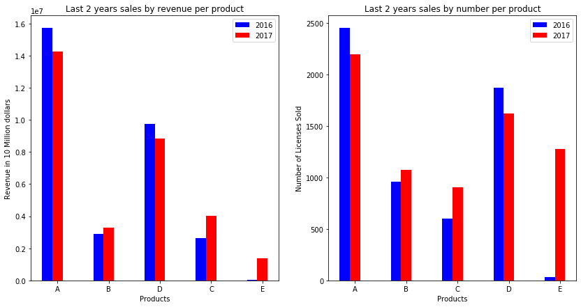

```python
fig = plt.figure(figsize=(14,7))
x = list(range(len(plot_data.keys())))
fig.add_subplot(121)
plt.bar([i -.2 for i in x],[round(plot_data[i][-2],2) for i in plot_data.keys()],width=0.2, color='b',label='2016');
plt.bar(x,[round(plot_data[i][-1],2) for i in plot_data.keys()],width=0.2, color='r',label='2017');
plt.xticks(x,list(plot_data.keys()));
plt.title("Last 2 years sales by revenue per product");
plt.xlabel("Products");
plt.ylabel("Revenue in 10 Million dollars");
plt.legend();

fig.add_subplot(122)
x = list(range(len(plot_numbers.keys())))
plt.bar([i -.2 for i in x],[round(plot_numbers[i][-2],2) for i in plot_numbers.keys()],width=0.2, color='b',label='2016');
plt.bar(x,[round(plot_numbers[i][-1],2) for i in plot_numbers.keys()],width=0.2, color='r',label='2017');
plt.xticks(x,list(plot_numbers.keys()));
plt.title("Last 2 years sales by number per product");
plt.xlabel("Products");
plt.ylabel("Number of Licenses Sold");
plt.legend();

plt.savefig("Last 2 years sales sales in terms if number and revenue per product");
plt.show();
```

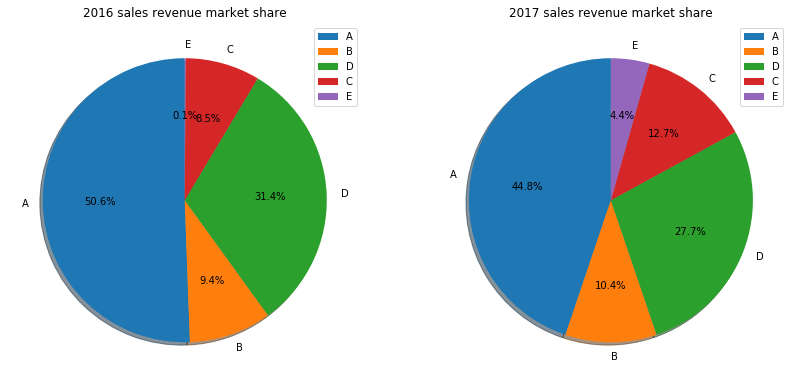

```python
fig = plt.figure(figsize=(14,7))
fig.add_subplot(121)
labels = list(plot_data.keys())
sizes = [round(plot_data[i][-2],2) for i in plot_data.keys()]
plt.pie(sizes,labels=labels,autopct='%1.1f%%',shadow=True, startangle=90)
plt.title("2016 sales revenue market share")
plt.legend()


fig.add_subplot(122)
labels = list(plot_data.keys())
sizes = [round(plot_data[i][-1],2) for i in plot_data.keys()]
plt.pie(sizes,labels=labels,autopct='%1.1f%%',shadow=True, startangle=90)
plt.title("2017 sales revenue market share")
plt.legend()


plt.savefig("Last 2 years sales revenue market share per product.png");
plt.show()
```

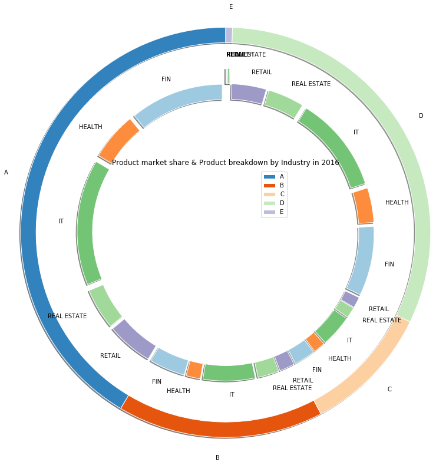

```python
fig, ax = plt.subplots()

size = 0.3
vals = np.array([y[(y['PRODUCT'] == 'A')&(y['year'] == 2016)]['licenses_industry']])
vals = np.append(vals, [np.array(y[(y['PRODUCT'] == 'B')&(y['year'] == 2016)]['licenses_industry'])],axis=0)
vals = np.append(vals, [np.array(y[(y['PRODUCT'] == 'C')&(y['year'] == 2016)]['licenses_industry'])],axis=0)
vals = np.append(vals, [np.array(y[(y['PRODUCT'] == 'D')&(y['year'] == 2016)]['licenses_industry'])],axis=0)
vals = np.append(vals, [np.array(y[(y['PRODUCT'] == 'E')&(y['year'] == 2016)]['licenses_industry'])],axis=0)
labels_outer = ['A','B','C','D','E']
labels_inner = ['FIN','HEALTH','IT','REAL ESTATE','RETAIL']*5

explode = (0.2,0.2,0.2,0.2,0.2,0.2,0.2,0.2,0.2,0.2,0.2,0.2,0.2,0.2,0.2,0.2,0.2,0.2,0.2,0.2,0.5,0.5,0.5,0.5,0.5)
cmap = plt.get_cmap("tab20c")
outer_colors = cmap(np.array([0,4,7,11,14]))
inner_colors = cmap(np.array([2,5,9,10,13]))

ax.pie(vals.sum(axis=1), labels= labels_outer, radius=4, colors=outer_colors,
       wedgeprops=dict(width=size, edgecolor='w'),shadow=True, startangle=90)

ax.pie(vals.flatten(), radius=3-size, colors=inner_colors, labels = labels_inner,explode=explode,
       wedgeprops=dict(width=size, edgecolor='w'),shadow=True, startangle=90)

ax.set(aspect="equal")
plt.legend(labels= labels_outer,loc='upper right')
plt.title("Product market share & Product breakdown by Industry in 2016")

#plt.savefig("Product market share & Product breakdown by Industry in 2016.png",fi);
plt.show()
```

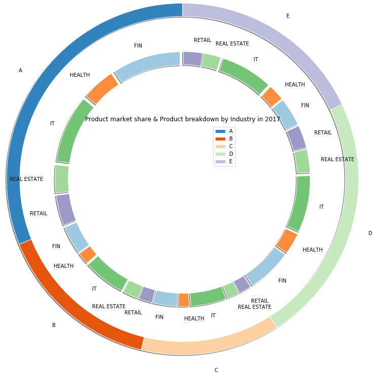

```python
fig, ax = plt.subplots()

size = 0.3
vals = np.array([y[(y['PRODUCT'] == 'A')&(y['year'] == 2017)]['licenses_industry']])
vals = np.append(vals, [np.array(y[(y['PRODUCT'] == 'B')&(y['year'] == 2017)]['licenses_industry'])],axis=0)
vals = np.append(vals, [np.array(y[(y['PRODUCT'] == 'C')&(y['year'] == 2017)]['licenses_industry'])],axis=0)
vals = np.append(vals, [np.array(y[(y['PRODUCT'] == 'D')&(y['year'] == 2017)]['licenses_industry'])],axis=0)
vals = np.append(vals, [np.array(y[(y['PRODUCT'] == 'E')&(y['year'] == 2017)]['licenses_industry'])],axis=0)
labels_outer = ['A','B','C','D','E']
labels_inner = ['FIN','HEALTH','IT','REAL ESTATE','RETAIL']*5

#explode = (0.2,0.2,0.2,0.2,0.2,0.2,0.2,0.2,0.2,0.2,0.2,0.2,0.2,0.2,0.2,0.2,0.2,0.2,0.2,0.2,0.5,0.5,0.5,0.5,0.5)
explode = (0.2,0.2,0.2,0.2,0.2)*5
cmap = plt.get_cmap("tab20c")
outer_colors = cmap(np.array([0,4,7,11,14]))
inner_colors = cmap(np.array([2,5,9,10,13]))

ax.pie(vals.sum(axis=1), labels= labels_outer, radius=4, colors=outer_colors,
       wedgeprops=dict(width=size, edgecolor='w'),shadow=True, startangle=90)

ax.pie(vals.flatten(), radius=3-size, colors=inner_colors, labels = labels_inner,explode=explode,
       wedgeprops=dict(width=size, edgecolor='w'),shadow=True, startangle=90)

ax.set(aspect="equal")
plt.legend(labels= labels_outer,loc='upper right')
plt.title("Product market share & Product breakdown by Industry in 2017")
plt.show()
```

# SLIDE 4 code and analysis

Now, there can be 2 possibilities of decline in sales and revenue of our top products The products have been faulty and there have been bugs reported and customers not satisfied Products don’t have issues, the industry has changed and products might be outdated by newer products in the market. Thus we need to see customer reviews across products and industry trends. The average customer satisfaction ranges between 6.5 to 7.5. This is poor! For a million dollar company like ours, we have a scope of improvement. Let’s dig deeper in customer satisfaction to device a strategy Finance industry is pretty stable. We can utilize their strategies to further increase our sales. 3 out of 5 products have declined in Retail so maybe a change in sale strategy by reatil team is required. Maybe we can adopt more customer centric strategies like Finance Team does.

# There can be two possibilities, either the product has a drawback and faults and that's why there's a decline in sales or we need to watch the trend in industry to get an early insight if the product is being outdated with time

# Checking customer satisfaction to get insights about product drawbacks and faults

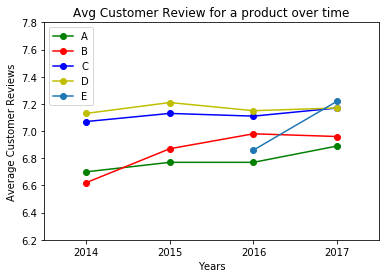

```python
plot_CS_products = dict()
for p in products:
    k = list()
    for y in years:
        a = sales_data[(sales_data['PRODUCT']==p)&(sales_data['year']==y)]
        b = sales_data[(sales_data['PRODUCT']==p)&(sales_data['year']==y)&(sales_data['CSat']!=0.0)]
        #for that particular year i'm giving the avg c review for that product across all the industry so
        #i can plot for each product a time line of customer reviews.
        k.append(round(a['PCS'].sum()/b['NUM_LICENSE'].sum(),2))
    plot_CS_products[p] = k

plt.plot(sales_data[sales_data['PRODUCT']=='A']['year'].unique(),plot_CS_products['A'],'g-',marker='o',label='A')
plt.plot(sales_data[sales_data['PRODUCT']=='B']['year'].unique(),plot_CS_products['B'],'r-',marker='o',label='B')
plt.plot(sales_data[sales_data['PRODUCT']=='C']['year'].unique(),plot_CS_products['C'],'b-',marker='o',label='C')
plt.plot(sales_data[sales_data['PRODUCT']=='D']['year'].unique(),plot_CS_products['D'],'y-',marker='o',label='D')
plt.plot(sales_data[sales_data['PRODUCT']=='E']['year'].unique(),plot_CS_products['E'][2:],'o-',marker='o',label='E')
plt.legend(loc=0)
plt.axis([2013.5, 2017.5, 6.2, 7.8])
plt.xlabel("Years")
plt.ylabel("Average Customer Reviews")
plt.xticks(sales_data['year'].unique());
plt.title("Avg Customer Review for a product over time");
plt.savefig("Avg Customer Review for a product over time.png");
```

We need to look at it from a greater depth

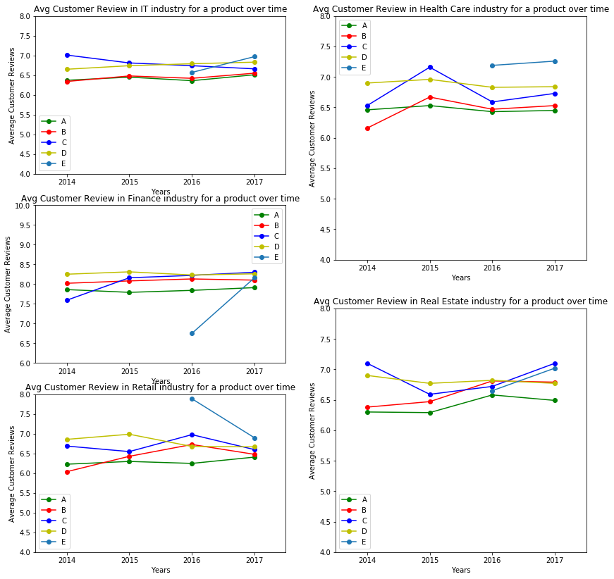

```python
products = sales_data['PRODUCT'].unique()
years = sales_data['year'].unique()
industries = sales_data['INDUSTRY'].unique()

sales_data['PCS'] = sales_data['NUM_LICENSE']*sales_data['CSat']
#sales_data[(sales_data['PRODUCT']=='E')&(sales_data['INDUSTRY']=='FINANCE')&(sales_data['year']==2016)]
plot_CS_industry = dict()
for i in industries:
    #k = list()
    plot_CS_product_ind = dict()
    for p in products:
        k = list()
        for y in years:
            a = sales_data[(sales_data['PRODUCT']==p)&(sales_data['INDUSTRY']==i)&(sales_data['year']==y)]
            b = sales_data[(sales_data['PRODUCT']==p)&(sales_data['INDUSTRY']==i)&(sales_data['year']==y)&(sales_data['CSat']!=0.0)]
            #for that particular year i'm giving the avg c review for that product for that industry so
            #i can plot for each industry a time line of customer reviews across products
            k.append(round(a['PCS'].sum()/b['NUM_LICENSE'].sum(),2))
        plot_CS_product_ind[p] = k
    plot_CS_industry[i] = plot_CS_product_ind

fig = plt.figure(figsize=(14,14))

#SEEING TRENDS ACROSS INDUSTRIES
#IT
fig.add_subplot(321)
plt.plot(sales_data[sales_data['PRODUCT']=='A']['year'].unique(),plot_CS_industry['IT']['A'],'g-',marker='o',label='A')
plt.plot(sales_data[sales_data['PRODUCT']=='B']['year'].unique(),plot_CS_industry['IT']['B'],'r-',marker='o',label='B')
plt.plot(sales_data[sales_data['PRODUCT']=='C']['year'].unique(),plot_CS_industry['IT']['C'],'b-',marker='o',label='C')
plt.plot(sales_data[sales_data['PRODUCT']=='D']['year'].unique(),plot_CS_industry['IT']['D'],'y-',marker='o',label='D')
plt.plot(sales_data[sales_data['PRODUCT']=='E']['year'].unique(),plot_CS_industry['IT']['E'][2:],'o-',marker='o',label='E')
plt.legend(loc=0)
plt.axis([2013.5, 2017.5, 4, 8])
plt.xticks(sales_data['year'].unique());
plt.xlabel("Years")
plt.ylabel("Average Customer Reviews")
plt.title("Avg Customer Review in IT industry for a product over time");


#FINANCE
fig.add_subplot(323)
plt.plot(sales_data[sales_data['PRODUCT']=='A']['year'].unique(),plot_CS_industry['FINANCE']['A'],'g-',marker='o',label='A')
plt.plot(sales_data[sales_data['PRODUCT']=='B']['year'].unique(),plot_CS_industry['FINANCE']['B'],'r-',marker='o',label='B')
plt.plot(sales_data[sales_data['PRODUCT']=='C']['year'].unique(),plot_CS_industry['FINANCE']['C'],'b-',marker='o',label='C')
plt.plot(sales_data[sales_data['PRODUCT']=='D']['year'].unique(),plot_CS_industry['FINANCE']['D'],'y-',marker='o',label='D')
plt.plot(sales_data[sales_data['PRODUCT']=='E']['year'].unique(),plot_CS_industry['FINANCE']['E'][2:],'o-',marker='o',label='E')
plt.legend(loc=0)
plt.axis([2013.5, 2017.5, 6, 10])
plt.xticks(sales_data['year'].unique());
plt.xlabel("Years")
plt.ylabel("Average Customer Reviews")
plt.title("Avg Customer Review in Finance industry for a product over time");




#RETAIL
fig.add_subplot(325)
plt.plot(sales_data[sales_data['PRODUCT']=='A']['year'].unique(),plot_CS_industry['RETAIL']['A'],'g-',marker='o',label='A')
plt.plot(sales_data[sales_data['PRODUCT']=='B']['year'].unique(),plot_CS_industry['RETAIL']['B'],'r-',marker='o',label='B')
plt.plot(sales_data[sales_data['PRODUCT']=='C']['year'].unique(),plot_CS_industry['RETAIL']['C'],'b-',marker='o',label='C')
plt.plot(sales_data[sales_data['PRODUCT']=='D']['year'].unique(),plot_CS_industry['RETAIL']['D'],'y-',marker='o',label='D')
plt.plot(sales_data[sales_data['PRODUCT']=='E']['year'].unique(),plot_CS_industry['RETAIL']['E'][2:],'o-',marker='o',label='E')
plt.legend(loc=0)
plt.axis([2013.5, 2017.5, 4, 8])
plt.xticks(sales_data['year'].unique());
plt.xlabel("Years")
plt.ylabel("Average Customer Reviews")
plt.title("Avg Customer Review in Retail industry for a product over time");



#HEALTHCARE
fig.add_subplot(222)
plt.plot(sales_data[sales_data['PRODUCT']=='A']['year'].unique(),plot_CS_industry['HEALTH CARE']['A'],'g-',marker='o',label='A')
plt.plot(sales_data[sales_data['PRODUCT']=='B']['year'].unique(),plot_CS_industry['HEALTH CARE']['B'],'r-',marker='o',label='B')
plt.plot(sales_data[sales_data['PRODUCT']=='C']['year'].unique(),plot_CS_industry['HEALTH CARE']['C'],'b-',marker='o',label='C')
plt.plot(sales_data[sales_data['PRODUCT']=='D']['year'].unique(),plot_CS_industry['HEALTH CARE']['D'],'y-',marker='o',label='D')
plt.plot(sales_data[sales_data['PRODUCT']=='E']['year'].unique(),plot_CS_industry['HEALTH CARE']['E'][2:],'o-',marker='o',label='E')
plt.legend(loc=0)
plt.axis([2013.5, 2017.5, 4, 8])
plt.xticks(sales_data['year'].unique());
plt.title("Avg Customer Review in Health Care industry for a product over time");
plt.xlabel("Years")
plt.ylabel("Average Customer Reviews")


#REAL ESTATE
fig.add_subplot(224)

plt.plot(sales_data[sales_data['PRODUCT']=='A']['year'].unique(),plot_CS_industry['REAL ESTATE']['A'],'g-',marker='o',label='A')
plt.plot(sales_data[sales_data['PRODUCT']=='B']['year'].unique(),plot_CS_industry['REAL ESTATE']['B'],'r-',marker='o',label='B')
plt.plot(sales_data[sales_data['PRODUCT']=='C']['year'].unique(),plot_CS_industry['REAL ESTATE']['C'],'b-',marker='o',label='C')
plt.plot(sales_data[sales_data['PRODUCT']=='D']['year'].unique(),plot_CS_industry['REAL ESTATE']['D'],'y-',marker='o',label='D')
plt.plot(sales_data[sales_data['PRODUCT']=='E']['year'].unique(),plot_CS_industry['REAL ESTATE']['E'][2:],'o-',marker='o',label='E')
plt.legend(loc=0)
plt.axis([2013.5, 2017.5, 4, 8])
plt.xticks(sales_data['year'].unique());
plt.title("Avg Customer Review in Real Estate industry for a product over time");
plt.xlabel("Years")
plt.ylabel("Average Customer Reviews")



plt.savefig("Average Customer Reviews across industries.png");
```

# SLIDE 5 code and analysis

The numbers of client dropped from 2016 to 2017 for product A is: 874 The numbers of client dropped from 2016 to 2017 for product B is: 348 The numbers of client dropped from 2016 to 2017 for product C is: 208 The numbers of client dropped from 2016 to 2017 for product D is: 652 Data shows that A and D have most number of client dropouts. Finance is stable. Retail needs improvement in customer satisfaction. But still why the decline? What about other industries. Let’s have a deeper look at general trends across the industries to find some other causes for decline in sales and further incorporate some strategies. A one of our top products sold less than previous year (2017-2016) in IT, Real Estate, Retail and Health Care. D sold less in all industries (2017-2016) One of the probable reason can be that industries have changed. These products came in market 4 years ago. Maybe they have become outdated and industries have more demands. Customers don't have bad reviews because products don't have any bugs but maybe industries need more functionalities now. Also E is a new upcoming product with high growth rate. Therefore more resources should be allocated to development of E's newer versions. Newer products/versions should be developed to replace current A and D.

```python
#A
client_A_2016 = sales_data[(sales_data['PRODUCT']=='A')&(sales_data['year']==2016)]['CLIENT_ID'].values.tolist()
client_A_2016 = set(client_A_2016)
client_A_2017 = sales_data[(sales_data['PRODUCT']=='A')&(sales_data['year']==2017)]['CLIENT_ID'].values.tolist()
client_A_2017 = set(client_A_2017)


#B
client_B_2016 = sales_data[(sales_data['PRODUCT']=='B')&(sales_data['year']==2016)]['CLIENT_ID'].values.tolist()
client_B_2016 = set(client_B_2016)
client_B_2017 = sales_data[(sales_data['PRODUCT']=='B')&(sales_data['year']==2017)]['CLIENT_ID'].values.tolist()
client_B_2017 = set(client_B_2017)


#C
client_C_2016 = sales_data[(sales_data['PRODUCT']=='C')&(sales_data['year']==2016)]['CLIENT_ID'].values.tolist()
client_C_2016 = set(client_C_2016)
client_C_2017 = sales_data[(sales_data['PRODUCT']=='C')&(sales_data['year']==2017)]['CLIENT_ID'].values.tolist()
client_C_2017 = set(client_C_2017)


#D
client_D_2016 = sales_data[(sales_data['PRODUCT']=='D')&(sales_data['year']==2016)]['CLIENT_ID'].values.tolist()
client_D_2016 = set(client_D_2016)
client_D_2017 = sales_data[(sales_data['PRODUCT']=='D')&(sales_data['year']==2017)]['CLIENT_ID'].values.tolist()
client_D_2017 = set(client_D_2017)


#E
client_E_2017 = sales_data[(sales_data['PRODUCT']=='E')&(sales_data['year']==2017)]['CLIENT_ID'].values.tolist()
client_E_2017 = set(client_E_2017)

"""
client_A_2017 = sales_data[(sales_data['PRODUCT']=='A')&(sales_data['year']==2017)]['CLIENT_ID'].drop_duplicates()
client_A_2017 = pd.DataFrame(client_A_2017).reset_index()
client_A_2017 = client_A_2017.drop(columns=['index'])
a_17 = client_A_2016.values.tolist()
a_17 = [i[0] for i in a_16]
a_17 = set(a_16)


client_E_2017 = sales_data[(sales_data['PRODUCT']=='E')&(sales_data['year']==2017)]['CLIENT_ID'].drop_duplicates()
client_E_2017 = pd.DataFrame(client_E_2017).reset_index()
client_E_2017 = client_E_2017.drop(columns=['index'])
""";

client_A_dropped = client_A_2016.difference(client_A_2017)
print("The numbers of client dropped from 2016 to 2017 for product A is: ",len(client_A_dropped))

client_B_dropped = client_B_2016.difference(client_B_2017)
print("The numbers of client dropped from 2016 to 2017 for product B is: ",len(client_B_dropped))

client_C_dropped = client_C_2016.difference(client_C_2017)
print("The numbers of client dropped from 2016 to 2017 for product C is: ",len(client_C_dropped))

client_D_dropped = client_D_2016.difference(client_D_2017)
print("The numbers of client dropped from 2016 to 2017 for product D is: ",len(client_D_dropped))
```

```
The numbers of client dropped from 2016 to 2017 for product A is:  874
The numbers of client dropped from 2016 to 2017 for product B is:  348
The numbers of client dropped from 2016 to 2017 for product C is:  208
The numbers of client dropped from 2016 to 2017 for product D is:  652
```

# More insights can be developed in terms of demographic clientele droppings so that we know which area needs more focus on sales teams

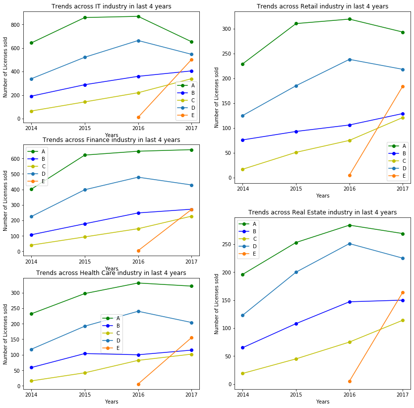

```python
y = pd.DataFrame(sales_data.groupby(['PRODUCT','year','INDUSTRY']).size())
y = y.rename(columns={0:'licenses_industry'})
y = y.reset_index(level=['PRODUCT','year','INDUSTRY'])

fig = plt.figure(figsize=(14,14))
years = y['year'].unique()
#SEEING TRENDS ACROSS INDUSTRIES
#IT
fig.add_subplot(321)
plt.plot(y[(y['PRODUCT'] == 'A') & (y['INDUSTRY'] == 'IT')]['year'],y[(y['PRODUCT'] == 'A') & (y['INDUSTRY'] == 'IT')]['licenses_industry'],'g-',marker='o',label='A')
plt.plot(y[(y['PRODUCT'] == 'B') & (y['INDUSTRY'] == 'IT')]['year'],y[(y['PRODUCT'] == 'B') & (y['INDUSTRY'] == 'IT')]['licenses_industry'],'b-',marker='o',label='B')
plt.plot(y[(y['PRODUCT'] == 'C') & (y['INDUSTRY'] == 'IT')]['year'],y[(y['PRODUCT'] == 'C') & (y['INDUSTRY'] == 'IT')]['licenses_industry'],'y-',marker='o',label='C')
plt.plot(y[(y['PRODUCT'] == 'D') & (y['INDUSTRY'] == 'IT')]['year'],y[(y['PRODUCT'] == 'D') & (y['INDUSTRY'] == 'IT')]['licenses_industry'],'o-',marker='o',label='D')
plt.plot(y[(y['PRODUCT'] == 'E') & (y['INDUSTRY'] == 'IT')]['year'],y[(y['PRODUCT'] == 'E') & (y['INDUSTRY'] == 'IT')]['licenses_industry'],'o-',marker='o',label='E')
plt.title("Trends across IT industry in last 4 years")
plt.legend(loc=0)
plt.xticks(years);
plt.xlabel("Years")
plt.ylabel("Number of Licenses sold")


#FINANCE
fig.add_subplot(323)
plt.plot(y[(y['PRODUCT'] == 'A') & (y['INDUSTRY'] == 'FINANCE')]['year'],y[(y['PRODUCT'] == 'A') & (y['INDUSTRY'] == 'FINANCE')]['licenses_industry'],'g-',marker='o',label='A')
plt.plot(y[(y['PRODUCT'] == 'B') & (y['INDUSTRY'] == 'FINANCE')]['year'],y[(y['PRODUCT'] == 'B') & (y['INDUSTRY'] == 'FINANCE')]['licenses_industry'],'b-',marker='o',label='B')
plt.plot(y[(y['PRODUCT'] == 'C') & (y['INDUSTRY'] == 'FINANCE')]['year'],y[(y['PRODUCT'] == 'C') & (y['INDUSTRY'] == 'FINANCE')]['licenses_industry'],'y-',marker='o',label='C')
plt.plot(y[(y['PRODUCT'] == 'D') & (y['INDUSTRY'] == 'FINANCE')]['year'],y[(y['PRODUCT'] == 'D') & (y['INDUSTRY'] == 'FINANCE')]['licenses_industry'],'o-',marker='o',label='D')
plt.plot(y[(y['PRODUCT'] == 'E') & (y['INDUSTRY'] == 'FINANCE')]['year'],y[(y['PRODUCT'] == 'E') & (y['INDUSTRY'] == 'FINANCE')]['licenses_industry'],'o-',marker='o',label='E')
plt.title("Trends across Finance industry in last 4 years")
plt.legend(loc=0)
plt.xticks(years);
plt.xlabel("Years")
plt.ylabel("Number of Licenses sold")


#HEALTH CARE
fig.add_subplot(325)
plt.plot(y[(y['PRODUCT'] == 'A') & (y['INDUSTRY'] == 'HEALTH CARE')]['year'],y[(y['PRODUCT'] == 'A') & (y['INDUSTRY'] == 'HEALTH CARE')]['licenses_industry'],'g-',marker='o',label='A')
plt.plot(y[(y['PRODUCT'] == 'B') & (y['INDUSTRY'] == 'HEALTH CARE')]['year'],y[(y['PRODUCT'] == 'B') & (y['INDUSTRY'] == 'HEALTH CARE')]['licenses_industry'],'b-',marker='o',label='B')
plt.plot(y[(y['PRODUCT'] == 'C') & (y['INDUSTRY'] == 'HEALTH CARE')]['year'],y[(y['PRODUCT'] == 'C') & (y['INDUSTRY'] == 'HEALTH CARE')]['licenses_industry'],'y-',marker='o',label='C')
plt.plot(y[(y['PRODUCT'] == 'D') & (y['INDUSTRY'] == 'HEALTH CARE')]['year'],y[(y['PRODUCT'] == 'D') & (y['INDUSTRY'] == 'HEALTH CARE')]['licenses_industry'],'o-',marker='o',label='D')
plt.plot(y[(y['PRODUCT'] == 'E') & (y['INDUSTRY'] == 'HEALTH CARE')]['year'],y[(y['PRODUCT'] == 'E') & (y['INDUSTRY'] == 'HEALTH CARE')]['licenses_industry'],'o-',marker='o',label='E')
plt.title("Trends across Health Care industry in last 4 years")
plt.legend(loc=0)
plt.xticks(years);
plt.xlabel("Years")
plt.ylabel("Number of Licenses sold")


#RETAIL
fig.add_subplot(222)
plt.plot(y[(y['PRODUCT'] == 'A') & (y['INDUSTRY'] == 'RETAIL')]['year'],y[(y['PRODUCT'] == 'A') & (y['INDUSTRY'] == 'RETAIL')]['licenses_industry'],'g-',marker='o',label='A')
plt.plot(y[(y['PRODUCT'] == 'B') & (y['INDUSTRY'] == 'RETAIL')]['year'],y[(y['PRODUCT'] == 'B') & (y['INDUSTRY'] == 'RETAIL')]['licenses_industry'],'b-',marker='o',label='B')
plt.plot(y[(y['PRODUCT'] == 'C') & (y['INDUSTRY'] == 'RETAIL')]['year'],y[(y['PRODUCT'] == 'C') & (y['INDUSTRY'] == 'RETAIL')]['licenses_industry'],'y-',marker='o',label='C')
plt.plot(y[(y['PRODUCT'] == 'D') & (y['INDUSTRY'] == 'RETAIL')]['year'],y[(y['PRODUCT'] == 'D') & (y['INDUSTRY'] == 'RETAIL')]['licenses_industry'],'o-',marker='o',label='D')
plt.plot(y[(y['PRODUCT'] == 'E') & (y['INDUSTRY'] == 'RETAIL')]['year'],y[(y['PRODUCT'] == 'E') & (y['INDUSTRY'] == 'RETAIL')]['licenses_industry'],'o-',marker='o',label='E')
plt.title("Trends across Retail industry in last 4 years")
plt.legend(loc=0)
plt.xticks(years);
plt.xlabel("Years")
plt.ylabel("Number of Licenses sold")


#REAL ESTATE
fig.add_subplot(224)
plt.plot(y[(y['PRODUCT'] == 'A') & (y['INDUSTRY'] == 'REAL ESTATE')]['year'],y[(y['PRODUCT'] == 'A') & (y['INDUSTRY'] == 'REAL ESTATE')]['licenses_industry'],'g-',marker='o',label='A')
plt.plot(y[(y['PRODUCT'] == 'B') & (y['INDUSTRY'] == 'REAL ESTATE')]['year'],y[(y['PRODUCT'] == 'B') & (y['INDUSTRY'] == 'REAL ESTATE')]['licenses_industry'],'b-',marker='o',label='B')
plt.plot(y[(y['PRODUCT'] == 'C') & (y['INDUSTRY'] == 'REAL ESTATE')]['year'],y[(y['PRODUCT'] == 'C') & (y['INDUSTRY'] == 'REAL ESTATE')]['licenses_industry'],'y-',marker='o',label='C')
plt.plot(y[(y['PRODUCT'] == 'D') & (y['INDUSTRY'] == 'REAL ESTATE')]['year'],y[(y['PRODUCT'] == 'D') & (y['INDUSTRY'] == 'REAL ESTATE')]['licenses_industry'],'o-',marker='o',label='D')
plt.plot(y[(y['PRODUCT'] == 'E') & (y['INDUSTRY'] == 'REAL ESTATE')]['year'],y[(y['PRODUCT'] == 'E') & (y['INDUSTRY'] == 'REAL ESTATE')]['licenses_industry'],'o-',marker='o',label='E')
plt.title("Trends across Real Estate industry in last 4 years")
plt.legend(loc=0)
plt.xticks(years);
plt.xlabel("Years")
plt.ylabel("Number of Licenses sold")


plt.savefig("Sales trends across industries in last 4 years.png")
#x[x['PRODUCT'] == 'B'].plot('year','sales_per_year',marker='o',label='B',xticks=x['year'])
```

# SLIDE 6 code and analysis

We have devised some good strategies, but let's extract some more info: We have devised the strategies but how to allocate resources? Which team should get the most funds? California one or Michigan one? Which sales team needs newer members? Which is an upcoming market? Let’s answer these questions Let’s see where our clients are based at: We have divided regions based on percentage of sales in geographic area. We realize California, Texas and NY are the states with highest sales (more than 10%) (number of licenses sold). Also, CO, NC, GA and IL are upcoming. Maybe these are the next software hubs like silicon valleys. We should explore these markets. Resources should be allocated based on this info for the strategies incorporated earlier.

```python
data = gpd.read_file('states_21basic/states.shp')
data = data[['STATE_ABBR','DRAWSEQ','geometry']]
data = data.rename(columns={"STATE_ABBR": "STATE"})
```

```python
"""
df = sales_data['STATE'].copy()

df = sales_data.groupby(['PRODUCT','INDUSTRY','STATE']).size()

geoinfect = geo.merge(inf, right_on = 'Country_Code', left_on = 'ADM0_A3')
Alternatively, you can reconstruct GeoDataFrame after the merge.

geoinfect = inf.merge(geo, left_on = 'Country_Code', right_on = 'ADM0_A3')
geoinfect = gpd.GeoDataFrame(geoinfect, crs=geo.crs)
"""
temp = pd.merge(sales_data, data, on='STATE')

temp2 = gpd.GeoDataFrame(temp)

temp3 = temp.loc[:,['STATE','geometry']]
temp3['Count'] = temp.groupby('STATE')['STATE'].transform('size')
temp3 = temp3.drop_duplicates()
temp3 = pd.merge(temp3,data[['STATE','geometry']],on='STATE',how='right',copy=False).drop(columns=['geometry_x'])
#temp3.fillna(value=0)
temp3['Count'] = temp3['Count'].fillna(0)
temp3['Per_sales'] = 100*(temp3['Count']/sum(temp3['Count']))
temp3 = temp3.rename(columns={"geometry_y": "geometry"})
temp3 = gpd.GeoDataFrame(temp3)
```

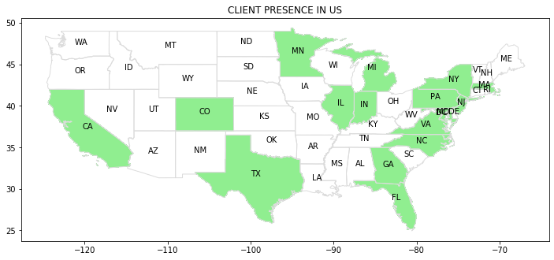

```python
data = data[(data.loc[:,'STATE'] != 'HI') & (data.loc[:,'STATE'] != 'AK')]

ax = data.plot(figsize=(12,12), color='none', edgecolor='gainsboro', zorder=3)
#df.plot(color='lightgreen', ax=ax)
data.apply(lambda x: ax.annotate(s=x.STATE, xy=x.geometry.centroid.coords[0], ha='center'),axis=1);
temp2[['STATE','geometry']].plot(color='lightgreen', ax=ax);
plt.title("CLIENT PRESENCE IN US");
plt.savefig("Client Presence in US.png")
```

```python
#Read data to json
merged_json = json.loads(temp3.to_json())

#Convert to str like object
json_data = json.dumps(merged_json)

#Input GeoJSON source that contains features for plotting.
geosource = GeoJSONDataSource(geojson = json_data)

#Define a sequential multi-hue color palette.
palette = brewer['YlGnBu'][5]

#Reverse color order so that dark blue is highest obesity.
palette = palette[::-1]

#Instantiate LinearColorMapper that linearly maps numbers in a range, into a sequence of colors.
color_mapper = LinearColorMapper(palette = palette, low = 0, high = 12)

#Define custom tick labels for color bar.
#tick_labels = {'0': '0%', '5': '5%', '10':'10%', '15':'15%', '999999':'20%', '25':'25%', '30':'30%','35':'35%', '40': '>40%'}

#Create color bar.
color_bar = ColorBar(color_mapper=color_mapper, label_standoff=8,width = 500, height = 20,
border_line_color=None,location = (0,0), orientation = 'horizontal')# major_label_overrides = tick_labels)

#Create figure object.
p = figure(title = "US Client Demographics based on number of licenses sold", plot_height = 600 , plot_width = 950, toolbar_location = None)
p.xgrid.grid_line_color = None
p.ygrid.grid_line_color = None

#Add patch renderer to figure.
p.patches('xs','ys', source = geosource,fill_color = {'field' :'Per_sales', 'transform' : color_mapper},
          line_color = 'black', line_width = 0.25, fill_alpha = 1)

#Specify figure layout.
p.add_layout(color_bar, 'below')

#Display figure inline in Jupyter Notebook.
output_notebook()

#Display figure.
show(p)
```

[interactive chart not shown]